# **Bank Churn Prediction**

### Improvement 4 - Different Learning Rates and Optimizers

```python
def create_improvement_model(learning_rate, optimizer):
    weighted_improvement_model = Sequential()

    weighted_improvement_model.add(Dense(64, input_shape = (train_features.shape[-1],), activation = 'relu'))
    weighted_improvement_model.add(Dense(1, activation = 'sigmoid'))

    if optimizer == "Adagrad":
        opt = keras.optimizers.Adagrad(lr = learning_rate)
    elif optimizer == "Adam":
        opt = keras.optimizers.Adam(lr = learning_rate)
    elif optimizer == "Adamax":
        opt = keras.optimizers.Adamax(lr = learning_rate)
    elif optimizer == "Nadam":
        opt = keras.optimizers.Nadam(lr = learning_rate)
    elif optimizer == "RMSprop":
        opt = keras.optimizers.RMSprop(lr = learning_rate)
    elif optimizer == "SGD":
        opt = keras.optimizers.SGD(lr = learning_rate)

    weighted_improvement_model.compile(optimizer = opt, loss = 'binary_crossentropy', metrics=METRICS)
    return weighted_improvement_model
```

```
********************************************************* Model : Class Weight - Adagrad - 0.01 *********************************************************
```

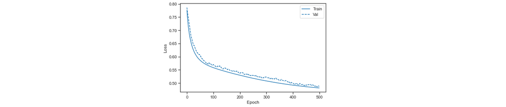

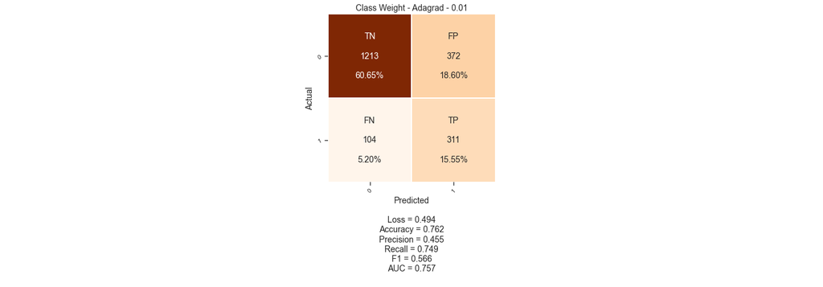

```
********************************************************* Model : Class Weight - Adagrad - 0.001 *********************************************************
```

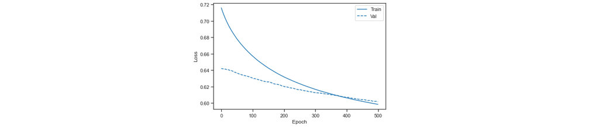

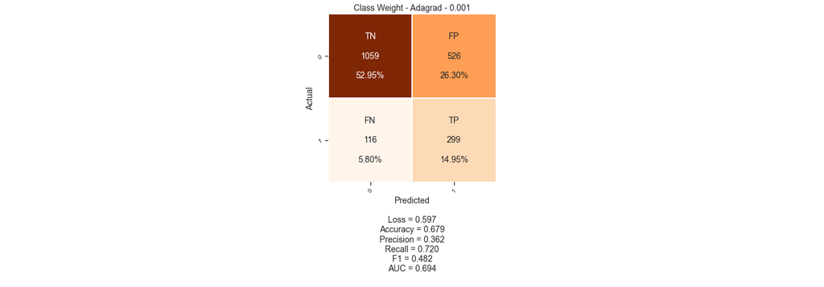

```
********************************************************* Model : Class Weight - Adam - 0.01 *********************************************************

WARNING:tensorflow:5 out of the last 13 calls to <function Model.make_predict_function.<locals>.predict_function at 0x15c0525e0> triggered tf.function retracing. Tracing is expensive and the excessive number of tracings could be due to (1) creating @tf.function repeatedly in a loop, (2) passing tens…
```

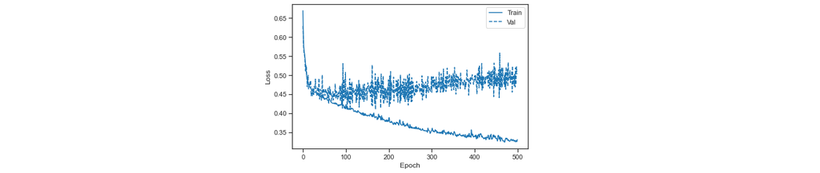

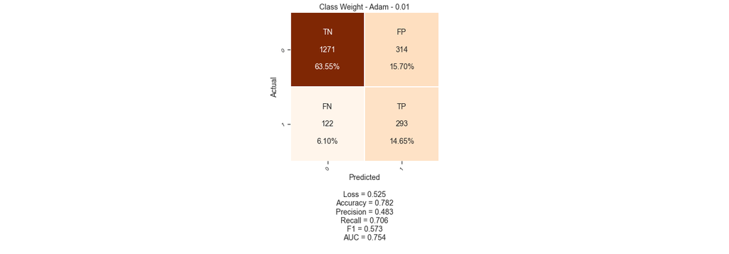

```
********************************************************* Model : Class Weight - Adam - 0.001 *********************************************************

WARNING:tensorflow:6 out of the last 14 calls to <function Model.make_predict_function.<locals>.predict_function at 0x15bfc6550> triggered tf.function retracing. Tracing is expensive and the excessive number of tracings could be due to (1) creating @tf.function repeatedly in a loop, (2) passing tens…
```

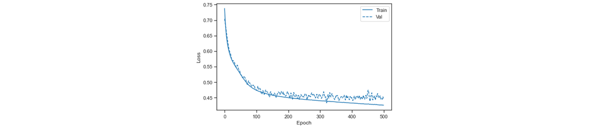

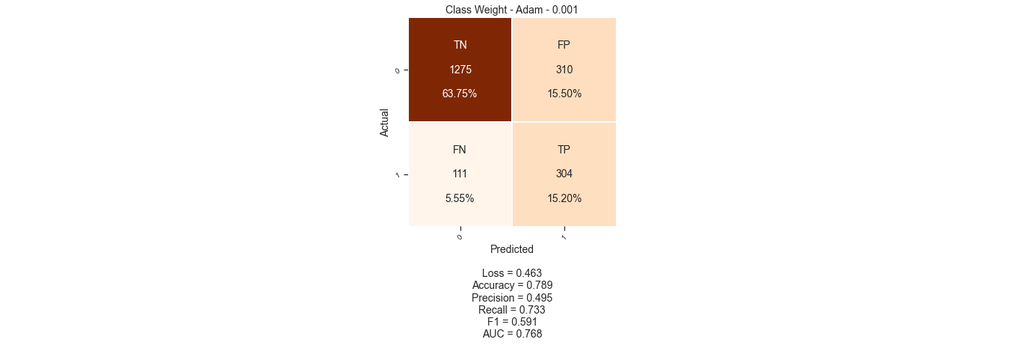

```
********************************************************* Model : Class Weight - Adamax - 0.01 *********************************************************

WARNING:tensorflow:7 out of the last 15 calls to <function Model.make_predict_function.<locals>.predict_function at 0x15d4a84c0> triggered tf.function retracing. Tracing is expensive and the excessive number of tracings could be due to (1) creating @tf.function repeatedly in a loop, (2) passing tens…
```

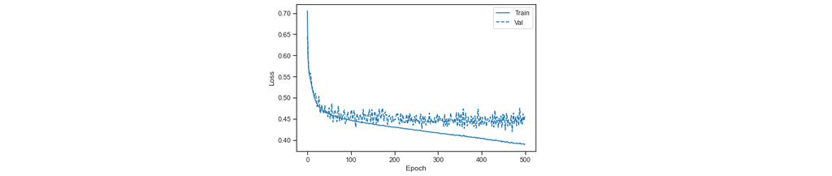

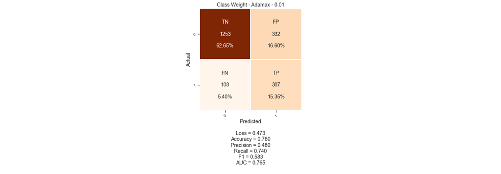

```
********************************************************* Model : Class Weight - Adamax - 0.001 *********************************************************

WARNING:tensorflow:7 out of the last 11 calls to <function Model.make_predict_function.<locals>.predict_function at 0x15d520940> triggered tf.function retracing. Tracing is expensive and the excessive number of tracings could be due to (1) creating @tf.function repeatedly in a loop, (2) passing tens…
```

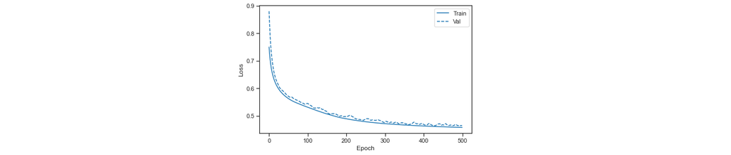

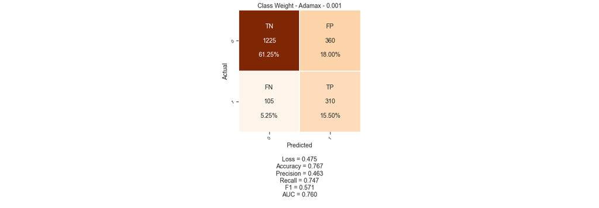

```
********************************************************* Model : Class Weight - Nadam - 0.01 *********************************************************

WARNING:tensorflow:8 out of the last 12 calls to <function Model.make_predict_function.<locals>.predict_function at 0x15bf31430> triggered tf.function retracing. Tracing is expensive and the excessive number of tracings could be due to (1) creating @tf.function repeatedly in a loop, (2) passing tens…
```

[12 more figures not shown]

```python
learning_rates = [0.01, 0.001]
optimizers = ["Adagrad", "Adam", "Adamax", "Nadam", "RMSprop", "SGD"]
descriptions = ["Class Weight - Adagrad - ", "Class Weight - Adam - ", "Class Weight - Adamax - ", "Class Weight - Nadam - ", "Class Weight - RMSprop - ", "Class Weight - SGD - "]
comp_index = 4

for opt, desc in zip(optimizers, descriptions):
    for learning_rate in learning_rates:
        new_desc = desc
        new_desc += str(learning_rate)
        print("")
        print("********************************************************* Model : {0} *********************************************************".format(new_desc))
        print("")
        new_model = create_improvement_model(learning_rate, opt)
        new_model_history = new_model.fit(
            train_features,
            train_labels,
            batch_size=BATCH_SIZE,
            epochs=EPOCHS,
            validation_data=(val_features, val_labels),
            verbose = False,
            # The class weights go here
            class_weight=class_weight)

        test_predictions_new_model = np.where(new_model.predict(test_features, batch_size=BATCH_SIZE) > THRESHOLD, 1, 0)
        new_model_results = new_model.evaluate(test_features, test_labels,batch_size=BATCH_SIZE, verbose=0)
        new_model_metrics = calculate_metrics(test_labels, test_predictions_new_model)

        plot_loss(new_model_history)

        fig_conf, axs = plt.subplots(nrows=1, ncols=3, figsize=(20,7))
        create_confusion_matrix(axs, 0, 1, new_desc, test_labels, test_predictions_new_model, new_model_results[0], new_model_metrics[0], new_model_metrics[1], new_model_metrics[2], new_model_metrics[3], new_model_metrics[4])
        axs[0].set_axis_off()
        axs[2].set_axis_off()
        fig_conf.tight_layout(pad=3.5)
        plt.show();

        model_comp_df.loc[comp_index] = [new_desc, new_model_results[0], new_model_metrics[0], new_model_metrics[1], new_model_metrics[2], new_model_metrics[3], new_model_metrics[4]]
        comp_index += 1

        print("")
        print("*************************************************************************************************************************************")
```

## Conclusion

So based on the models above, we notice the following results

```python
display(HTML(model_comp_df.to_html()))
```

|  | Model | Loss | Accuracy | Precision | Recall | F1 | AUC |
| --- | --- | --- | --- | --- | --- | --- | --- |
| 0 | Baseline | 0.354009 | 0.8530 | 0.728302 | 0.465060 | 0.567647 | 0.709817 |
| 1 | Class Weight | 0.463803 | 0.7865 | 0.490354 | 0.734940 | 0.588235 | 0.767470 |
| 2 | Oversampled | 0.466465 | 0.7855 | 0.488599 | 0.722892 | 0.583090 | 0.762392 |
| 3 | Class Weight - 2 Layers | 0.479667 | 0.7790 | 0.478261 | 0.715663 | 0.573359 | 0.755623 |
| 4 | Class Weight - Adagrad - 0.01 | 0.493994 | 0.7620 | 0.455344 | 0.749398 | 0.566485 | 0.757349 |
| 5 | Class Weight - Adagrad - 0.001 | 0.596728 | 0.6790 | 0.362424 | 0.720482 | 0.482258 | 0.694310 |
| 6 | Class Weight - Adam - 0.01 | 0.524917 | 0.7820 | 0.482702 | 0.706024 | 0.573386 | 0.753958 |
| 7 | Class Weight - Adam - 0.001 | 0.463157 | 0.7895 | 0.495114 | 0.732530 | 0.590865 | 0.768473 |
| 8 | Class Weight - Adamax - 0.01 | 0.472914 | 0.7800 | 0.480438 | 0.739759 | 0.582543 | 0.765148 |
| 9 | Class Weight - Adamax - 0.001 | 0.474580 | 0.7675 | 0.462687 | 0.746988 | 0.571429 | 0.759929 |
| 10 | Class Weight - Nadam - 0.01 | 0.456906 | 0.8020 | 0.518812 | 0.631325 | 0.569565 | 0.739006 |
| 11 | Class Weight - Nadam - 0.001 | 0.453958 | 0.7910 | 0.497529 | 0.727711 | 0.590998 | 0.767641 |
| 12 | Class Weight - RMSprop - 0.01 | 0.433544 | 0.8205 | 0.559072 | 0.638554 | 0.596175 | 0.753347 |
| 13 | Class Weight - RMSprop - 0.001 | 0.461176 | 0.7860 | 0.489922 | 0.761446 | 0.596226 | 0.776937 |
| 14 | Class Weight - SGD - 0.01 | 0.552710 | 0.7380 | 0.423562 | 0.727711 | 0.535461 | 0.734202 |
| 15 | Class Weight - SGD - 0.001 | 0.652965 | 0.6250 | 0.314917 | 0.686747 | 0.431818 | 0.647790 |

- Almost all the models show good improvement in **Recall** compared to the baseline model.
- If the bank feels that reaching out to customer who dont intend to exit, is not ok, then the bank should choose a model that has good **Precision** and the table above should give a good idea of the performance of the models
- Also since there is an imbalance in the classes of the data, it made the problem difficult. We can try other methods to address this, like:
  - SMOTE
  - Providing proper initial bias to Tensorflow (as discussed in https://www.tensorflow.org/tutorials/structured_data/imbalanced_data#optional_set_the_correct_initial_bias)